# R Notebook

**Principles of Data Visualization and Introduction to ggplot2**

I have provided you with data about the 5,000 fastest growing companies in the US, as compiled by Inc. magazine. lets read this in:

```r
inc <- read.csv("https://raw.githubusercontent.com/charleyferrari/CUNY_DATA_608/master/module1/Data/inc5000_data.csv", header= TRUE)
```

And lets preview this data:

```r
head(inc)
```

|  | Rank | Name | Growth_Rate | Revenue | Industry | Employees | City | State |
| --- | --- | --- | --- | --- | --- | --- | --- | --- |
| 1 | 1 | Fuhu | 421.48 | 1.179e+08 | Consumer Products & Services | 104 | El Segundo | CA |
| 2 | 2 | FederalConference.com | 248.31 | 4.960e+07 | Government Services | 51 | Dumfries | VA |
| 3 | 3 | The HCI Group | 245.45 | 2.550e+07 | Health | 132 | Jacksonville | FL |
| 4 | 4 | Bridger | 233.08 | 1.900e+09 | Energy | 50 | Addison | TX |
| 5 | 5 | DataXu | 213.37 | 8.700e+07 | Advertising & Marketing | 220 | Boston | MA |
| 6 | 6 | MileStone Community Builders | 179.38 | 4.570e+07 | Real Estate | 63 | Austin | TX |

```r
summary(inc)
```

```
      Rank                          Name       Growth_Rate         Revenue
 Min.   :   1   (Add)ventures         :   1   Min.   :  0.340   Min.   :2.000e+06
 1st Qu.:1252   @Properties           :   1   1st Qu.:  0.770   1st Qu.:5.100e+06
 Median :2502   1-Stop Translation USA:   1   Median :  1.420   Median :1.090e+07
 Mean   :2502   110 Consulting        :   1   Mean   :  4.612   Mean   :4.822e+07
 3rd Qu.:3751   11thStreetCoffee.com  :   1   3rd Qu.:  3.290   3rd Qu.:2.860e+07
 Max.   :5000   123 Exteriors         :   1   Max.   :421.480   Max.   :1.010e+10
                (Other)               :4995
                         Industry      Employees                  City          State
 IT Services                 : 733   Min.   :    1.0   New York     : 160   CA     : 701
 Business Products & Services: 482   1st Qu.:   25.0   Chicago      :  90   TX     : 387
 Advertising & Marketing     : 471   Median :   53.0   Austin       :  88   NY     : 311
 Health                      : 355   Mean   :  232.7   Houston      :  76   VA     : 283
 Software                    : 342   3rd Qu.:  132.0   San Francisco:  75   FL     : 282
 Financial Services          : 260   Max.   :66803.0   Atlanta      :  74   IL     : 273
 (Other)                     :2358   NA's   :12        (Other)      :4438   (Other):2764
```

Think a bit on what these summaries mean. Use the space below to add some more relevant non-visual exploratory information you think helps you understand this data:

```r
print(colnames(inc))
```

```
[1] "Rank"        "Name"        "Growth_Rate" "Revenue"     "Industry"    "Employees"   "City"
[8] "State"
```

What exactly is the data about? The column names help with that.

```r
sapply(inc, class)
```

```
       Rank        Name Growth_Rate     Revenue    Industry   Employees        City       State
  "integer"    "factor"   "numeric"   "numeric"    "factor"   "integer"    "factor"    "factor"
```

So does identifying the data in each column without sifting through it.

```r
revenue_by_industry <- data.frame(t(sapply(levels(inc$Industry), function(x) summary(inc[inc$Industry==x,]$Revenue))))
revenue_by_industry
```

|  | Min. | X1st.Qu. | Median | Mean | X3rd.Qu. | Max. |
| --- | --- | --- | --- | --- | --- | --- |
| Advertising & Marketing | 2000000 | 4100000 | 7900000 | 16528662 | 14950000 | 3.568e+08 |
| Business Products & Services | 2000000 | 4700000 | 9850000 | 54705187 | 25400000 | 2.400e+09 |
| Computer Hardware | 3800000 | 12950000 | 22350000 | 270129545 | 48775000 | 1.010e+10 |
| Construction | 2100000 | 7000000 | 14000000 | 70450802 | 34300000 | 4.700e+09 |
| Consumer Products & Services | 2000000 | 4000000 | 9400000 | 73676847 | 20800000 | 4.600e+09 |
| Education | 2000000 | 3850000 | 6800000 | 13726506 | 13250000 | 1.457e+08 |
| Energy | 2100000 | 8600000 | 29400000 | 126344954 | 108100000 | 1.900e+09 |
| Engineering | 2100000 | 5950000 | 12100000 | 34222973 | 27075000 | 6.887e+08 |
| Environmental Services | 2100000 | 5150000 | 12500000 | 51741176 | 35000000 | 1.400e+09 |
| Financial Services | 2000000 | 6000000 | 15550000 | 50580385 | 47125000 | 9.591e+08 |

[output cut: 15 more lines]

Each industry produces revenue, and having it all collected in a single place lets us pick out which industries are the most profitable.

```r
employees_by_industry <- data.frame(t(sapply(levels(inc$Industry), function(x) summary(na.omit(inc[inc$Industry==x,]$Employees)))))
employees_by_industry
```

|  | Min. | X1st.Qu. | Median | Mean | X3rd.Qu. | Max. |
| --- | --- | --- | --- | --- | --- | --- |
| Advertising & Marketing | 2 | 22.00 | 37.0 | 84.35456 | 74.00 | 5637 |
| Business Products & Services | 4 | 24.00 | 49.0 | 244.49375 | 127.00 | 32000 |
| Computer Hardware | 6 | 27.00 | 45.5 | 220.77273 | 85.25 | 6800 |
| Construction | 3 | 24.00 | 47.0 | 155.60963 | 113.50 | 6549 |
| Consumer Products & Services | 1 | 17.00 | 34.0 | 223.96059 | 79.00 | 13200 |
| Education | 1 | 22.00 | 44.0 | 92.59036 | 100.00 | 850 |
| Energy | 2 | 25.00 | 70.0 | 242.54128 | 245.00 | 2501 |
| Engineering | 11 | 35.50 | 64.0 | 276.14865 | 146.75 | 10000 |
| Environmental Services | 4 | 30.00 | 67.0 | 199.11765 | 122.00 | 5347 |
| Financial Services | 5 | 28.00 | 70.0 | 183.43462 | 190.50 | 1829 |

[output cut: 15 more lines]

Knowing how many employees there are for each industry’s businesses also is informative.

```r
employee_val_by_industry <- revenue_by_industry/employees_by_industry
employee_val_by_industry[order(employee_val_by_industry$Mean, decreasing=TRUE),]
```

|  | Min. | X1st.Qu. | Median | Mean | X3rd.Qu. | Max. |
| --- | --- | --- | --- | --- | --- | --- |
| Computer Hardware | 633333.3 | 479629.6 | 491208.8 | 1223563.93 | 572140.76 | 1485294.12 |
| Energy | 1050000.0 | 344000.0 | 420000.0 | 520921.44 | 441224.49 | 759696.12 |
| Construction | 700000.0 | 291666.7 | 297872.3 | 452740.64 | 302202.64 | 717666.82 |
| Logistics & Transportation | 2300000.0 | 394444.4 | 416000.0 | 368674.17 | 273595.51 | 175925.93 |
| Consumer Products & Services | 2000000.0 | 235294.1 | 276470.6 | 328972.37 | 263291.14 | 348484.85 |
| Insurance | 385714.3 | 210687.0 | 238679.2 | 318558.39 | 323670.21 | 185957.59 |
| Manufacturing | 2100000.0 | 229166.7 | 242857.1 | 287525.67 | 283534.14 | 200000.00 |
| Retail | 1000000.0 | 330769.2 | 264516.1 | 276718.46 | 286227.54 | 481017.01 |
| Financial Services | 400000.0 | 214285.7 | 222142.9 | 275740.67 | 247375.33 | 524384.91 |
| Environmental Services | 525000.0 | 171666.7 | 186567.2 | 259852.29 | 286885.25 | 261829.06 |

[output cut: 15 more lines]

On average, the industries who have the most revenue per employee are Computer Hardware, Energy, Construction, Logistics & Transportation, and Consumer Products & Services.

```r
employee_val_by_industry[order(employee_val_by_industry$`Min.`, decreasing=TRUE),]
```

|  | Min. | X1st.Qu. | Median | Mean | X3rd.Qu. | Max. |
| --- | --- | --- | --- | --- | --- | --- |
| Logistics & Transportation | 2300000.0 | 394444.4 | 416000.0 | 368674.17 | 273595.51 | 175925.93 |
| Manufacturing | 2100000.0 | 229166.7 | 242857.1 | 287525.67 | 283534.14 | 200000.00 |
| Consumer Products & Services | 2000000.0 | 235294.1 | 276470.6 | 328972.37 | 263291.14 | 348484.85 |
| Education | 2000000.0 | 175000.0 | 154545.5 | 148249.84 | 132500.00 | 171411.76 |
| Software | 2000000.0 | 153125.0 | 126087.0 | 158339.45 | 145588.24 | 162500.00 |
| Energy | 1050000.0 | 344000.0 | 420000.0 | 520921.44 | 441224.49 | 759696.12 |
| Media | 1050000.0 | 233766.2 | 223529.4 | 182794.80 | 207865.17 | 133787.88 |
| Real Estate | 1050000.0 | 305000.0 | 261224.5 | 155338.34 | 268577.08 | 216227.52 |
| Advertising & Marketing | 1000000.0 | 186363.6 | 213513.5 | 195942.71 | 202027.03 | 63296.08 |
| Health | 1000000.0 | 172093.0 | 160563.4 | 216099.49 | 168250.00 | 615034.17 |

[output cut: 15 more lines]

The industries with the greatest minimum revenue per employee are Logistics & Transportiation, Manufacturing, Consumer Products & Services, Education, and Software.

## Question 1

Create a graph that shows the distribution of companies in the dataset by State (ie how many are in each state). There are a lot of States, so consider which axis you should use. This visualization is ultimately going to be consumed on a ‘portrait’ oriented screen (ie taller than wide), which should further guide your layout choices.

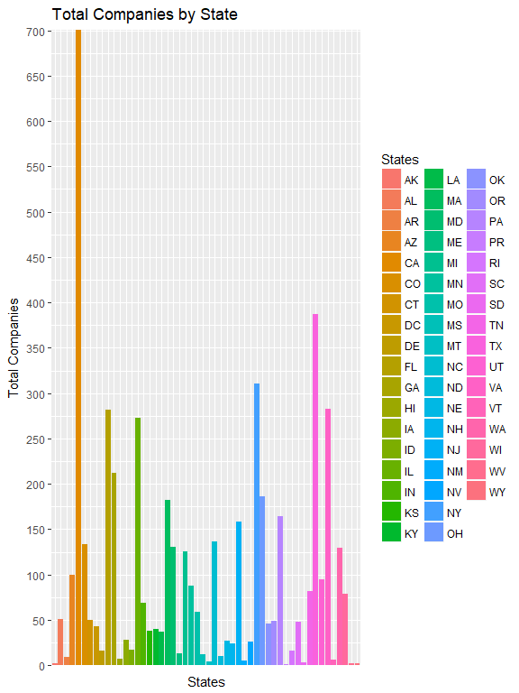

```r
library(ggplot2)
# barplot(summary(inc$State), las=2, cex.names=0.5, col="pink", main="Number of Companies by State") # Not bad, but base R... ggplot...
ggplot() +
  geom_histogram(aes(inc$State, fill=inc$State), stat="count", position = position_dodge(0.5)) +
  labs(x = "States", y="Total Companies", title="Total Companies by State", fill="States") +
  scale_color_gradient(low="blue", high="red") +
  scale_y_continuous(breaks=seq(0, 800, 50), expand = c(0, 0)) +
  theme(axis.text.x = element_blank(), axis.ticks.x = element_blank())
```

## Quesiton 2

Lets dig in on the state with the 3rd most companies in the data set. Imagine you work for the state and are interested in how many people are employed by companies in different industries. Create a plot that shows the average and/or median employment by industry for companies in this state (only use cases with full data, use R’s `complete.cases()` function.) In addition to this, your graph should show how variable the ranges are, and you should deal with outliers.

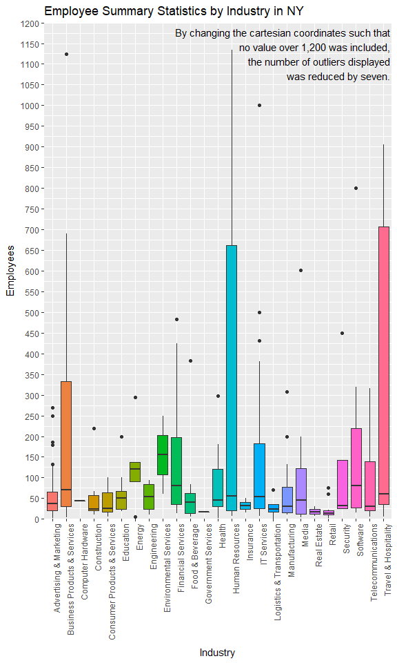

```r
state_3rd_most <- names(sort(table(inc$State), decreasing=TRUE)[3])
ggplot(data=inc[complete.cases(inc) & inc$State==state_3rd_most,]) +
  geom_boxplot(aes(x=Industry, y=Employees, fill=Industry)) +
  coord_cartesian(ylim=c(0,1200)) +
  theme(axis.text.x = element_text(angle = 90, hjust = 1)) +
  labs(title=paste("Employee Summary Statistics by Industry in", state_3rd_most)) +
  annotate("text", label="By changing the cartesian coordinates such that\nno value over 1,200 was included,\nthe number of outliers displayed\nwas reduced by seven.", x=25.5, y=1125, hjust = 1) +
  scale_y_continuous(breaks=seq(0, 1200, 50), expand = c(0, 0)) +
  guides(fill=FALSE)
```

## Question 3

Now imagine you work for an investor and want to see which industries generate the most revenue per employee. Create a chart that makes this information clear. Once again, the distribution per industry should be shown.

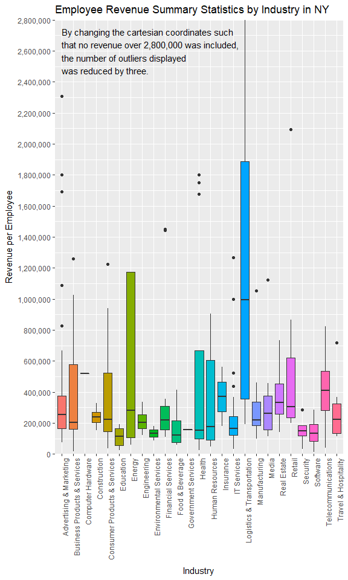

```r
ggplot(data=inc[complete.cases(inc) & inc$State==state_3rd_most,]) +
  geom_boxplot(aes(x=Industry, y=Revenue/Employees, fill=Industry)) +
  coord_cartesian(ylim=c(0,2800000)) +
  theme(axis.text.x = element_text(angle = 90, hjust = 1)) +
  labs(title=paste("Employee Revenue Summary Statistics by Industry in", state_3rd_most), y = "Revenue per Employee") +
  annotate("text", label="By changing the cartesian coordinates such\nthat no revenue over 2,800,000 was included,\nthe number of outliers displayed\nwas reduced by three.", x=1, y=2600000, hjust = 0) +
  scale_y_continuous(breaks=seq(0, 2800000, 200000), labels=scales::comma, expand=c(0,0)) +
  guides(fill=FALSE)
```